# Manipulating data with `dplyr`

Felix Lennert

knit on 2020-06-22

# Introduction

The last session showed you four things: how you get datasets into R, a couple of ways to create tibbles, how to pass data to functions using the pipe (`%>%`), and an introduction to tidy data and how to make datasets tidy using the `tidyr` package (Wickham 2020b).

What you didn’t learn was how you can actually manipulate the data itself. In the `tidyverse` framework (Wickham et al. 2019), the package which enables you to accomplish those tasks is `dplyr` (Wickham 2020a). It joined the party in 2014, building upon the `plyr` package. The d in `dplyr` stands for dataset and `dplyr` works with tibbles (or data frames) only.

It consists of five main functions, “verbs”:

- `arrange()` – sort values
- `filter()` – pick observations
- `mutate()` – create new variables (columns)
- `select()` – select variables
- `summarize()` – create summaries from multiple values

They are joined by `group_by()`, a function that changes the scope on which entities the functions are applied to.

In the following, I will guide you through how you can use the verbs to accomplish whatever goals which require data wrangling you might have.

The dataset I will use here consists of the 1,000 most popular movies on IMDb which were published between 2006 and 2016 and some data on them. It was created by PromptCloud and DataStock and published on Kaggle, more information can be found [here](https://www.kaggle.com/PromptCloudHQ/imdb-data).

```r
library(tidyverse)
imdb_raw <- read_csv("data/imdb2006-2016.csv")
```

The dataset hasn’t been modified by me before. I will show you how I would go across it using a couple of `dplyr` functions.

# `select()`

`select` enables you to *select* columns. Since we are dealing with tidy data, every variable has its own column.

`glimpse()` provides you with an overview of the dataset and its columns.

```r
glimpse(imdb_raw)
```

```
## Rows: 1,000
## Columns: 12
## $ Rank                 <dbl> 1, 2, 3, 4, 5, 6, 7, 8, 9, 10, 11, 12, 13, 14, 1…
## $ Title                <chr> "Guardians of the Galaxy", "Prometheus", "Split"…
## $ Genre                <chr> "Action,Adventure,Sci-Fi", "Adventure,Mystery,Sc…
## $ Description          <chr> "A group of intergalactic criminals are forced t…
## $ Director             <chr> "James Gunn", "Ridley Scott", "M. Night Shyamala…
## $ Actors               <chr> "Chris Pratt, Vin Diesel, Bradley Cooper, Zoe Sa…
## $ Year                 <dbl> 2014, 2012, 2016, 2016, 2016, 2016, 2016, 2016, …
## $ `Runtime (Minutes)`  <dbl> 121, 124, 117, 108, 123, 103, 128, 89, 141, 116,…
## $ Rating               <dbl> 8.1, 7.0, 7.3, 7.2, 6.2, 6.1, 8.3, 6.4, 7.1, 7.0…
## $ Votes                <dbl> 757074, 485820, 157606, 60545, 393727, 56036, 25…
## $ `Revenue (Millions)` <dbl> 333.13, 126.46, 138.12, 270.32, 325.02, 45.13, 1…
## $ Metascore            <dbl> 76, 65, 62, 59, 40, 42, 93, 71, 78, 41, 66, 74, …
```

The columns I want to keep are: `Title`, `Director`, `Year`, `Runtime (Minutes)`, `Rating`, `Votes`, and `Revenue (Millions`. Furthermore, I want to rename the columns: every column’s name should be in lowercase and a regular name that does not need to be surrounded by back ticks – i.e., a name that only consists of characters, numbers, underscores, or dots.

This can be achieved in a couple of ways:

First, by choosing the columns column by column and subsequently renaming them:

```r
imdb_raw %>%
  select(Title, Director, Year, `Runtime (Minutes)`, Rating, Votes, `Revenue (Millions)`) %>%
  rename(title = Title, director = Director, year = Year, runtime = `Runtime (Minutes)`, rating = Rating, votes = Votes, revenue_million = `Revenue (Millions)`) %>%
  glimpse()
```

```
## Rows: 1,000
## Columns: 7
## $ title           <chr> "Guardians of the Galaxy", "Prometheus", "Split", "Si…
## $ director        <chr> "James Gunn", "Ridley Scott", "M. Night Shyamalan", "…
## $ year            <dbl> 2014, 2012, 2016, 2016, 2016, 2016, 2016, 2016, 2016,…
## $ runtime         <dbl> 121, 124, 117, 108, 123, 103, 128, 89, 141, 116, 133,…
## $ rating          <dbl> 8.1, 7.0, 7.3, 7.2, 6.2, 6.1, 8.3, 6.4, 7.1, 7.0, 7.5…
## $ votes           <dbl> 757074, 485820, 157606, 60545, 393727, 56036, 258682,…
## $ revenue_million <dbl> 333.13, 126.46, 138.12, 270.32, 325.02, 45.13, 151.06…
```

Second, the columns can also be chosen vice versa: unnecessary columns can be dropped using a minus:

```r
imdb_raw %>%
  select(-Rank, -Genre, -Description, -Actors, -Metascore) %>%
  rename(title = Title, director = Director, year = Year, runtime = `Runtime (Minutes)`, rating = Rating, votes = Votes, revenue_million = `Revenue (Millions)`) %>%
  glimpse()
```

```
## Rows: 1,000
## Columns: 7
## $ title           <chr> "Guardians of the Galaxy", "Prometheus", "Split", "Si…
## $ director        <chr> "James Gunn", "Ridley Scott", "M. Night Shyamalan", "…
## $ year            <dbl> 2014, 2012, 2016, 2016, 2016, 2016, 2016, 2016, 2016,…
## $ runtime         <dbl> 121, 124, 117, 108, 123, 103, 128, 89, 141, 116, 133,…
## $ rating          <dbl> 8.1, 7.0, 7.3, 7.2, 6.2, 6.1, 8.3, 6.4, 7.1, 7.0, 7.5…
## $ votes           <dbl> 757074, 485820, 157606, 60545, 393727, 56036, 258682,…
## $ revenue_million <dbl> 333.13, 126.46, 138.12, 270.32, 325.02, 45.13, 151.06…
```

Columns can also be renamed in the selecting process:

```r
imdb_raw %>%
  select(title = Title, director = Director, year = Year, runtime = `Runtime (Minutes)`, rating = Rating, votes = Votes, revenue_million = `Revenue (Millions)`) %>%
  glimpse()
```

```
## Rows: 1,000
## Columns: 7
## $ title           <chr> "Guardians of the Galaxy", "Prometheus", "Split", "Si…
## $ director        <chr> "James Gunn", "Ridley Scott", "M. Night Shyamalan", "…
## $ year            <dbl> 2014, 2012, 2016, 2016, 2016, 2016, 2016, 2016, 2016,…
## $ runtime         <dbl> 121, 124, 117, 108, 123, 103, 128, 89, 141, 116, 133,…
## $ rating          <dbl> 8.1, 7.0, 7.3, 7.2, 6.2, 6.1, 8.3, 6.4, 7.1, 7.0, 7.5…
## $ votes           <dbl> 757074, 485820, 157606, 60545, 393727, 56036, 258682,…
## $ revenue_million <dbl> 333.13, 126.46, 138.12, 270.32, 325.02, 45.13, 151.06…
```

You can also make your expressions shorter by using a couple of hacks:

`:` can be used to select all columns between two:

```r
imdb_raw %>%
  select(Title, Director, Year:`Revenue (Millions)`) %>%
  rename(title = Title, director = Director, year = Year, runtime = `Runtime (Minutes)`, rating = Rating, votes = Votes, revenue_million = `Revenue (Millions)`) %>%
  glimpse()
```

```
## Rows: 1,000
## Columns: 7
## $ title           <chr> "Guardians of the Galaxy", "Prometheus", "Split", "Si…
## $ director        <chr> "James Gunn", "Ridley Scott", "M. Night Shyamalan", "…
## $ year            <dbl> 2014, 2012, 2016, 2016, 2016, 2016, 2016, 2016, 2016,…
## $ runtime         <dbl> 121, 124, 117, 108, 123, 103, 128, 89, 141, 116, 133,…
## $ rating          <dbl> 8.1, 7.0, 7.3, 7.2, 6.2, 6.1, 8.3, 6.4, 7.1, 7.0, 7.5…
## $ votes           <dbl> 757074, 485820, 157606, 60545, 393727, 56036, 258682,…
## $ revenue_million <dbl> 333.13, 126.46, 138.12, 270.32, 325.02, 45.13, 151.06…
```

`starts_with()` select columns whose name starts with the same character string:

```r
imdb_selected <- imdb_raw %>%
  select(Title, Director, Votes, Year, starts_with("R")) %>%
  select(-Rank) %>%
  rename(title = Title, director = Director, year = Year, runtime = `Runtime (Minutes)`, rating = Rating, votes = Votes, revenue_million = `Revenue (Millions)`) %>%
  glimpse()
```

```
## Rows: 1,000
## Columns: 7
## $ title           <chr> "Guardians of the Galaxy", "Prometheus", "Split", "Si…
## $ director        <chr> "James Gunn", "Ridley Scott", "M. Night Shyamalan", "…
## $ votes           <dbl> 757074, 485820, 157606, 60545, 393727, 56036, 258682,…
## $ year            <dbl> 2014, 2012, 2016, 2016, 2016, 2016, 2016, 2016, 2016,…
## $ runtime         <dbl> 121, 124, 117, 108, 123, 103, 128, 89, 141, 116, 133,…
## $ rating          <dbl> 8.1, 7.0, 7.3, 7.2, 6.2, 6.1, 8.3, 6.4, 7.1, 7.0, 7.5…
## $ revenue_million <dbl> 333.13, 126.46, 138.12, 270.32, 325.02, 45.13, 151.06…
```

As you may have noticed, the order in the `select()` matters: columns will be ordered in the same manner as they are chosen.

A couple of further shortcuts for `select()` do exist. An overview can be found in the [`dplyr` cheatsheet](https://github.com/rstudio/cheatsheets/blob/master/data-transformation.pdf).

# `filter()`

Whereas `select()` enables you to choose variables (i.e., columns), `filter()` lets you choose observations (i.e., rows).

In this case, I only want movies with a revenue above $100,000,000:

```r
imdb_selected %>%
  filter(revenue_million > 100) %>%
  glimpse()
```

```
## Rows: 250
## Columns: 7
## $ title           <chr> "Guardians of the Galaxy", "Prometheus", "Split", "Si…
## $ director        <chr> "James Gunn", "Ridley Scott", "M. Night Shyamalan", "…
## $ votes           <dbl> 757074, 485820, 157606, 60545, 393727, 258682, 192177…
## $ year            <dbl> 2014, 2012, 2016, 2016, 2016, 2016, 2016, 2016, 2016,…
## $ runtime         <dbl> 121, 124, 117, 108, 123, 128, 116, 133, 127, 133, 107…
## $ rating          <dbl> 8.1, 7.0, 7.3, 7.2, 6.2, 8.3, 7.0, 7.5, 7.8, 7.9, 7.7…
## $ revenue_million <dbl> 333.13, 126.46, 138.12, 270.32, 325.02, 151.06, 100.0…
```

Besides, I am especially interested in the director Christopher Nolan. Therefore, I want to look at movies that were directed by him and made more than $100,000,000:

```r
imdb_selected %>%
  filter(revenue_million > 100 & director == "Christopher Nolan") %>%
  glimpse()
```

```
## Rows: 4
## Columns: 7
## $ title           <chr> "Interstellar", "The Dark Knight", "Inception", "The …
## $ director        <chr> "Christopher Nolan", "Christopher Nolan", "Christophe…
## $ votes           <dbl> 1047747, 1791916, 1583625, 1222645
## $ year            <dbl> 2014, 2008, 2010, 2012
## $ runtime         <dbl> 169, 152, 148, 164
## $ rating          <dbl> 8.6, 9.0, 8.8, 8.5
## $ revenue_million <dbl> 187.99, 533.32, 292.57, 448.13
```

The following overview is taken from the [`dplyr` cheatsheet](https://github.com/rstudio/cheatsheets/blob/master/data-transformation.pdf) and shows the operators you can use in `filter()`:

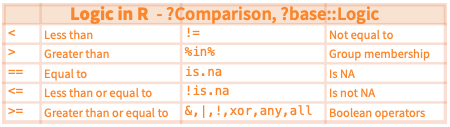

Overview of comparison operators

## Exemplary application

To demonstrate how a real-world application of this stuff could look like, I will now provide you a brief insight into my private life and how I organize movie nights. JK. You could definitely try this at home and surprise your loved ones with such hot applications. If you are brave and surprise your latest Tinder match with an .RDS file containing suggestions for Netflix&Chill, please let me know what their response looked like.

Tonight, I will hang out with a real nerd. Probably because they (nerds have all kinds of genders) know about my faible for R, they have sent me a vector containing a couple of movies we could watch tonight:

```r
set.seed(123) # guarantees that movie_vec will always be the same thing
movie_vec <- imdb_raw$Title[sample(1000
                                   , 10, replace = FALSE)]
movie_vec
```

```
##  [1] "Mechanic: Resurrection" "Denial"                 "The Conjuring 2"
##  [4] "Birth of the Dragon"    "Warrior"                "Super"
##  [7] "127 Hours"              "Dangal"                 "The Infiltrator"
## [10] "Maleficent"
```

However, I want to make a more informed decision and decide to obtain some more information on the movies from my IMDb dataset:

```r
imdb_selected %>%
  filter(title %in% movie_vec) %>%
  glimpse()
```

```
## Rows: 10
## Columns: 7
## $ title           <chr> "Dangal", "The Conjuring 2", "Warrior", "Maleficent",…
## $ director        <chr> "Nitesh Tiwari", "James Wan", "Gavin O'Connor", "Robe…
## $ votes           <dbl> 48969, 137203, 355722, 268877, 43929, 48161, 8229, 55…
## $ year            <dbl> 2016, 2016, 2011, 2014, 2016, 2016, 2016, 2016, 2010,…
## $ runtime         <dbl> 161, 134, 140, 97, 127, 98, 109, 103, 94, 96
## $ rating          <dbl> 8.8, 7.4, 8.2, 7.0, 7.1, 5.6, 6.6, 3.9, 7.6, 6.8
## $ revenue_million <dbl> 11.15, 102.46, 13.65, 241.41, 15.43, 21.20, 4.07, 93.…
```

I have convinced them to watch either one of the movies they have suggested or one directed by Christopher Nolan or one with a rating greater or equal to 8.5 and send them back this dataset:

```r
imdb_selected %>%
  filter(title %in% movie_vec | director == "Christopher Nolan" | rating >= 8.5) %>%
  glimpse()
```

```
## Rows: 21
## Columns: 7
## $ title           <chr> "Interstellar", "The Dark Knight", "The Prestige", "I…
## $ director        <chr> "Christopher Nolan", "Christopher Nolan", "Christophe…
## $ votes           <dbl> 1047747, 1791916, 913152, 1583625, 34110, 937414, 489…
## $ year            <dbl> 2014, 2008, 2006, 2010, 2016, 2006, 2016, 2012, 2014,…
## $ runtime         <dbl> 169, 152, 130, 148, 106, 151, 161, 164, 107, 134, 140…
## $ rating          <dbl> 8.6, 9.0, 8.5, 8.8, 8.6, 8.5, 8.8, 8.5, 8.5, 7.4, 8.2…
## $ revenue_million <dbl> 187.99, 533.32, 53.08, 292.57, 4.68, 132.37, 11.15, 4…
```

“I deteste ‘Interstellar’,” is the response. “All right,” I say to myself, “I can easily exclude it.”

```r
imdb_selected %>%
  filter(title %in% movie_vec | director == "Christopher Nolan" | rating >= 8.5 & title != "Interstellar") %>% # if you want to negate something, put the ! in front of it
  glimpse()
```

```
## Rows: 21
## Columns: 7
## $ title           <chr> "Interstellar", "The Dark Knight", "The Prestige", "I…
## $ director        <chr> "Christopher Nolan", "Christopher Nolan", "Christophe…
## $ votes           <dbl> 1047747, 1791916, 913152, 1583625, 34110, 937414, 489…
## $ year            <dbl> 2014, 2008, 2006, 2010, 2016, 2006, 2016, 2012, 2014,…
## $ runtime         <dbl> 169, 152, 130, 148, 106, 151, 161, 164, 107, 134, 140…
## $ rating          <dbl> 8.6, 9.0, 8.5, 8.8, 8.6, 8.5, 8.8, 8.5, 8.5, 7.4, 8.2…
## $ revenue_million <dbl> 187.99, 533.32, 53.08, 292.57, 4.68, 132.37, 11.15, 4…
```

Oh, that did not work. I should wrap them in columns:

```r
imdb_selected %>%
  filter((title %in% movie_vec | director == "Christopher Nolan" | rating >= 8.5) & title != "Interstellar") %>%
  glimpse()
```

```
## Rows: 20
## Columns: 7
## $ title           <chr> "The Dark Knight", "The Prestige", "Inception", "Kimi…
## $ director        <chr> "Christopher Nolan", "Christopher Nolan", "Christophe…
## $ votes           <dbl> 1791916, 913152, 1583625, 34110, 937414, 48969, 12226…
## $ year            <dbl> 2008, 2006, 2010, 2016, 2006, 2016, 2012, 2014, 2016,…
## $ runtime         <dbl> 152, 130, 148, 106, 151, 161, 164, 107, 134, 140, 97,…
## $ rating          <dbl> 9.0, 8.5, 8.8, 8.6, 8.5, 8.8, 8.5, 8.5, 7.4, 8.2, 7.0…
## $ revenue_million <dbl> 533.32, 53.08, 292.57, 4.68, 132.37, 11.15, 448.13, 1…
```

They come up with a new idea: we have a Scottish evening with a movie directed by the Scottish director Gillies MacKinnon:

```r
imdb_selected %>%
  filter(director == "Gillies MacKinnon") %>%
  glimpse()
```

```
## Rows: 1
## Columns: 7
## $ title           <chr> "Whisky Galore"
## $ director        <chr> "Gillies MacKinnon"
## $ votes           <dbl> 102
## $ year            <dbl> 2016
## $ runtime         <dbl> 98
## $ rating          <dbl> 5
## $ revenue_million <dbl> NA
```

“Well, apparently there is a problem in the dataset,” I notice. “There is an NA in the revenue column. I should probably have a further look at this.”

```r
imdb_selected %>%
  filter(is.na(revenue_million)) %>%
  glimpse()
```

```
## Rows: 128
## Columns: 7
## $ title           <chr> "Mindhorn", "Hounds of Love", "Paris pieds nus", "5- …
## $ director        <chr> "Sean Foley", "Ben Young", "Dominique Abel", "Patrick…
## $ votes           <dbl> 2490, 1115, 222, 241, 496, 5103, 987, 35870, 149791, …
## $ year            <dbl> 2016, 2016, 2016, 2007, 2016, 2016, 2016, 2016, 2016,…
## $ runtime         <dbl> 89, 108, 83, 113, 73, 91, 130, 86, 133, 106, 105, 118…
## $ rating          <dbl> 6.4, 6.7, 6.8, 7.1, 2.7, 5.6, 3.7, 6.8, 5.9, 7.9, 5.8…
## $ revenue_million <dbl> NA, NA, NA, NA, NA, NA, NA, NA, NA, NA, NA, NA, NA, N…
```

Well, that’s quite a significant number of NAs. I will need to exclude these cases:

```r
imdb_selected %>%
  filter(!is.na(revenue_million)) %>%
  glimpse()
```

```
## Rows: 872
## Columns: 7
## $ title           <chr> "Guardians of the Galaxy", "Prometheus", "Split", "Si…
## $ director        <chr> "James Gunn", "Ridley Scott", "M. Night Shyamalan", "…
## $ votes           <dbl> 757074, 485820, 157606, 60545, 393727, 56036, 258682,…
## $ year            <dbl> 2014, 2012, 2016, 2016, 2016, 2016, 2016, 2016, 2016,…
## $ runtime         <dbl> 121, 124, 117, 108, 123, 103, 128, 141, 116, 133, 127…
## $ rating          <dbl> 8.1, 7.0, 7.3, 7.2, 6.2, 6.1, 8.3, 7.1, 7.0, 7.5, 7.8…
## $ revenue_million <dbl> 333.13, 126.46, 138.12, 270.32, 325.02, 45.13, 151.06…
```

## Other possibilities to subset observations

`slice()` selects rows by positions:

```r
imdb_selected %>%
  slice(1:10) %>%
  glimpse()
```

```
## Rows: 10
## Columns: 7
## $ title           <chr> "Guardians of the Galaxy", "Prometheus", "Split", "Si…
## $ director        <chr> "James Gunn", "Ridley Scott", "M. Night Shyamalan", "…
## $ votes           <dbl> 757074, 485820, 157606, 60545, 393727, 56036, 258682,…
## $ year            <dbl> 2014, 2012, 2016, 2016, 2016, 2016, 2016, 2016, 2016,…
## $ runtime         <dbl> 121, 124, 117, 108, 123, 103, 128, 89, 141, 116
## $ rating          <dbl> 8.1, 7.0, 7.3, 7.2, 6.2, 6.1, 8.3, 6.4, 7.1, 7.0
## $ revenue_million <dbl> 333.13, 126.46, 138.12, 270.32, 325.02, 45.13, 151.06…
```

`distinct` removes duplicate rows:

```r
imdb_selected %>%
  distinct(director) %>%
  glimpse()
```

```
## Rows: 644
## Columns: 1
## $ director <chr> "James Gunn", "Ridley Scott", "M. Night Shyamalan", "Christo…
```

```r
imdb_selected %>%
  distinct(director) %>%
  glimpse()
```

```
## Rows: 644
## Columns: 1
## $ director <chr> "James Gunn", "Ridley Scott", "M. Night Shyamalan", "Christo…
```

By default, it will remove all other columns apart from the one(s) you have specified. You can avoid that by setting `.keep_all = TRUE`:

```r
imdb_selected %>%
  distinct(title, .keep_all = TRUE) %>%
  glimpse()
```

```
## Rows: 999
## Columns: 7
## $ title           <chr> "Guardians of the Galaxy", "Prometheus", "Split", "Si…
## $ director        <chr> "James Gunn", "Ridley Scott", "M. Night Shyamalan", "…
## $ votes           <dbl> 757074, 485820, 157606, 60545, 393727, 56036, 258682,…
## $ year            <dbl> 2014, 2012, 2016, 2016, 2016, 2016, 2016, 2016, 2016,…
## $ runtime         <dbl> 121, 124, 117, 108, 123, 103, 128, 89, 141, 116, 133,…
## $ rating          <dbl> 8.1, 7.0, 7.3, 7.2, 6.2, 6.1, 8.3, 6.4, 7.1, 7.0, 7.5…
## $ revenue_million <dbl> 333.13, 126.46, 138.12, 270.32, 325.02, 45.13, 151.06…
```

Oh, interesting, there is apparently one movie which is in there twice. How could we find this movie? (Exercise 1)

# `mutate()`

My dataset looks pretty nice already, but one flaw catches the eye: the column `revenue_million` should probably be converted to `revenue`. Hence, I need to create a new variable which contains the values from `revenue_million` multiplied by 1,000,000 and drop the now obsolete `revenue_million`.

```r
imdb_selected %>%
  mutate(revenue = revenue_million * 1000000) %>%
  select(-revenue_million) %>%
  glimpse()
```

```
## Rows: 1,000
## Columns: 7
## $ title    <chr> "Guardians of the Galaxy", "Prometheus", "Split", "Sing", "S…
## $ director <chr> "James Gunn", "Ridley Scott", "M. Night Shyamalan", "Christo…
## $ votes    <dbl> 757074, 485820, 157606, 60545, 393727, 56036, 258682, 2490, …
## $ year     <dbl> 2014, 2012, 2016, 2016, 2016, 2016, 2016, 2016, 2016, 2016, …
## $ runtime  <dbl> 121, 124, 117, 108, 123, 103, 128, 89, 141, 116, 133, 127, 1…
## $ rating   <dbl> 8.1, 7.0, 7.3, 7.2, 6.2, 6.1, 8.3, 6.4, 7.1, 7.0, 7.5, 7.8, …
## $ revenue  <dbl> 333130000, 126460000, 138120000, 270320000, 325020000, 45130…
```

The structure of the `mutate()` call looks like this: first, you need to provide the name of the new variable. If the variable exists already, it will be replaced. Second, the equal sign to tell R what the new variable should contain. Third, a function that outputs a vector which is as long as the tibble has rows or 1.

If we want to drop all other columns and just keep the new one: transmute()` drops all the original columns.

```r
imdb_selected %>%
  transmute(revenue = revenue_million * 1000000) %>%
  glimpse()
```

```
## Rows: 1,000
## Columns: 1
## $ revenue <dbl> 333130000, 126460000, 138120000, 270320000, 325020000, 451300…
```

`mutate()` uses so-called *window functions*. They take one vector of values and return another vector of values. An overview – again, from the cheatsheet:

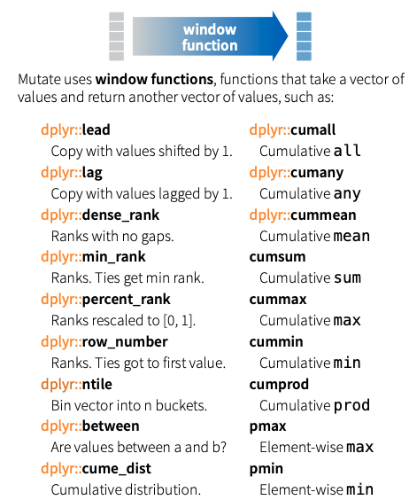

Window functions

Another feature of `dplyr`, which is useful in combination with mutate, is `case_when()`. This is a vectorized form of `if_else()` which will be introduced in the script on flow control.

`case_when()` can for instance be used to create binary indicator variables. In this example I want it to be 0 if the movie was made before 2010 and 1 if not.

```r
imdb_selected %>%
  mutate(indicator = case_when(year < 2010 ~ 0,
                               year >= 2010 ~ 1)) %>%
  glimpse()
```

```
## Rows: 1,000
## Columns: 8
## $ title           <chr> "Guardians of the Galaxy", "Prometheus", "Split", "Si…
## $ director        <chr> "James Gunn", "Ridley Scott", "M. Night Shyamalan", "…
## $ votes           <dbl> 757074, 485820, 157606, 60545, 393727, 56036, 258682,…
## $ year            <dbl> 2014, 2012, 2016, 2016, 2016, 2016, 2016, 2016, 2016,…
## $ runtime         <dbl> 121, 124, 117, 108, 123, 103, 128, 89, 141, 116, 133,…
## $ rating          <dbl> 8.1, 7.0, 7.3, 7.2, 6.2, 6.1, 8.3, 6.4, 7.1, 7.0, 7.5…
## $ revenue_million <dbl> 333.13, 126.46, 138.12, 270.32, 325.02, 45.13, 151.06…
## $ indicator       <dbl> 1, 1, 1, 1, 1, 1, 1, 1, 1, 1, 1, 1, 1, 1, 1, 1, 1, 1,…
```

Keep in mind that you can throw anything into `mutate()` as long as it is vectorized and the output has the same length as the tibble or 1.

# `summarize()` and `group_by`

When you analyze data, you often want to compare entities according to some sort of summary statistic. This means that you, first, need to split up your dataset into certain groups which share one or more characteristics, and, second, collapse the columns together into single-row summaries. The former challenge is accomplished using `group_by()` whose argument is one or more variables, the latter requires the `summarize()` function. This function works similar to `mutate()` but uses *summary functions* – which take a vector of multiple values and return a single value – instead of window functions – which return a vector of the same length as the input.

Let me provide you an example.

I am interested in the director’s average ratings:

```r
imdb_selected %>%
  group_by(director) %>%
  summarize(avg_rating = mean(rating))
```

```
## # A tibble: 644 x 2
##    director            avg_rating
##    <chr>                    <dbl>
##  1 Aamir Khan                 8.5
##  2 Abdellatif Kechiche        7.8
##  3 Adam Leon                  6.5
##  4 Adam McKay                 7
##  5 Adam Shankman              6.3
##  6 Adam Wingard               5.9
##  7 Afonso Poyart              6.4
##  8 Aisling Walsh              7.8
##  9 Akan Satayev               6.3
## 10 Akiva Schaffer             6.7
## # … with 634 more rows
```

In general, `summarize()` always works like this: first, you change the scope from the entire tibble to different groups. Then, you calculate your summary. If you then want to further manipulate your date or calculate something else based on the new summary, you need to call `ungroup()`.

You can see the summary functions below:

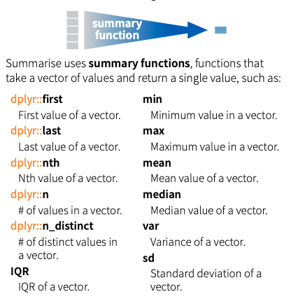

Summary functions in R

Another handy function akin to this is `count()`. It counts all occurrences of a singular value in the tibble.

If I were interested in how many movies of the different directors have made it into the dataset, I could use this code:

```r
imdb_selected %>%
  count(director)
```

```
## # A tibble: 644 x 2
##    director                n
##    <chr>               <int>
##  1 Aamir Khan              1
##  2 Abdellatif Kechiche     1
##  3 Adam Leon               1
##  4 Adam McKay              4
##  5 Adam Shankman           2
##  6 Adam Wingard            2
##  7 Afonso Poyart           1
##  8 Aisling Walsh           1
##  9 Akan Satayev            1
## 10 Akiva Schaffer          1
## # … with 634 more rows
```

Beyond that, you can also use `group_by()` with mutate. If you do so, the rows will not be collapsed together as in `summarize()`.

# `arrange()`

Finally, you can also sort values using `arrange()`. In the last section, I was interested in directors’ respective average ratings. The values were ordered according to their name (hence, “Aamir Khan” was first). In this case, this order dos not make too much sense, because the first name does not say too much about the director’s ratings. Therefore, I want to sort them according to their average ratings:

```r
imdb_selected %>%
  group_by(director) %>%
  summarize(avg_rating = mean(rating)) %>%
  arrange(avg_rating)
```

```
## # A tibble: 644 x 2
##    director           avg_rating
##    <chr>                   <dbl>
##  1 Jason Friedberg           1.9
##  2 James Wong                2.7
##  3 Shawn Burkett             2.7
##  4 Jonathan Holbrook         3.2
##  5 Femi Oyeniran             3.5
##  6 Micheal Bafaro            3.5
##  7 Jeffrey G. Hunt           3.7
##  8 Rolfe Kanefsky            3.9
##  9 Joey Curtis               4
## 10 Sam Taylor-Johnson        4.1
## # … with 634 more rows
```

All right, Jason Friedberg is apparently the director of the worst rated movie in my dataset. But it would be more handy, if they were arranged in descending order. I can use `desc()` for this:

```r
imdb_selected %>%
  group_by(director) %>%
  summarize(avg_rating = mean(rating)) %>%
  arrange(desc(avg_rating))
```

```
## # A tibble: 644 x 2
##    director                         avg_rating
##    <chr>                                 <dbl>
##  1 Nitesh Tiwari                          8.8
##  2 Christopher Nolan                      8.68
##  3 Makoto Shinkai                         8.6
##  4 Olivier Nakache                        8.6
##  5 Aamir Khan                             8.5
##  6 Florian Henckel von Donnersmarck       8.5
##  7 Damien Chazelle                        8.4
##  8 Naoko Yamada                           8.4
##  9 Amber Tamblyn                          8.3
## 10 Lee Unkrich                            8.3
## # … with 634 more rows
```

Chapeau, Nitesh Tiwari!

# Further links

- [Chapter in R4DS](https://r4ds.had.co.nz/transform.html)
- More on window functions in the vignette: `vignette("window-functions")`
- Again, [the cheatsheet](https://github.com/rstudio/cheatsheets/blob/master/data-transformation.pdf)
- A [tutorial on YouTube](https://www.youtube.com/watch?v=jWjqLW-u3hc)

# Exercises

1. Find the duplicated movie. How could you go across this?
2. Which director has made the longest movie?
3. What’s the highest ranked movie?
4. Which movie got the most votes?
5. Which movie had the biggest revenue in 2016?
6. How much revenue made the movies in the dataset every year in total?

Wickham, Hadley. 2020a. “Dplyr: A Grammar of Data Manipulation.”

Wickham, Hadley. 2020b. “Tidyr: Tidy Messy Data.”

Wickham, Hadley, Mara Averick, Jennifer Bryan, Winston Chang, Lucy McGowan, Romain François, Garrett Grolemund, Alex Hayes, Lionel Henry, Jim Hester, Max Kuhn, Thomas Pedersen, Evan Miller, Stephan Bache, Kirill Müller, Jeroen Ooms, David Robinson, Dana Seidel, Vitalie Spinu, Kohske Takahashi, Davis Vaughan, Claus Wilke, Kara Woo, and Hiroaki Yutani. 2019. “Welcome to the Tidyverse.” *Journal of Open Source Software* 4(43):1686.